# Human Activity Recognition - practical machine learning

Junho Song

26 Oct, 2015

# 1 Background

In this project, as prctical machin learning course of cousera we are going to anlyize HAR(human activity recognition) data. The folowing is overview of data sets.

===== In this project, your goal will be to use data from accelerometers on the belt, forearm, arm, and dumbell of 6 participants. They were asked to perform barbell lifts correctly and incorrectly in 5 different ways. More information is available from the website here: http://groupware.les.inf.puc-rio.br/har (see the section on the Weight Lifting Exercise Dataset).

Six young health participants were asked to perform one set of 10 repetitions of the Unilateral Dumbbell Biceps Curl in five different fashions: 1)exactly according to the specification (Class A), 2)throwing the elbows to the front (Class B), 3)lifting the dumbbell only halfway (Class C), 4)lowering the dumbbell only halfway (Class D) and 5)throwing the hips to the front (Class E). =====

# 2 Data PreProcessing

Set data folder

```r
filePath <- "/Users/uxLab/Box Sync/PROJECTS/MOOC/Johns Hopkins - Data Science/8 Practical Machine Learning/project/data/"
```

Check the original data set

```r
fileNameTraining <- "pml-training.csv"
fileNameTesting <- "pml-testing.csv"

fileUrlTraining <- "https://d396qusza40orc.cloudfront.net/predmachlearn/pml-training.csv"
fileUrlTesting <- "https://d396qusza40orc.cloudfront.net/predmachlearn/pml-testing.csv"
```

Load data sets

```r
fileTraining <- paste0(filePath, fileNameTraining)
fileTesting <- paste0(filePath, fileNameTesting)

if (!file.exists(fileTraining)) {
  download.file(fileUrlTraining, destfile = fileTraining, method ="curl")
  dateDownloaded <- date()
}

if (!file.exists(fileTesting)) {
  download.file(fileUrlTesting, destfile = fileTesting, method ="curl")
  dateDownloaded <- date()
}
```

Read each data

```r
pmlTraining <- read.csv(fileTraining)
pmlTesting <- read.csv(fileTesting)
```

# 3 Exploratory Data Analysis

Check out the data

```r
#names(pmlTraining)
#names(pmlTesting)
```

We are going to predict the factor in the 160th column ‘classe’, labelled A, B, C, C, E.

```r
pmlTraining[,c("classe")][1:10]    #check 160th cloumn name
```

```
##  [1] A A A A A A A A A A
## Levels: A B C D E
```

```r
pmlTesting[,c("problem_id")][1:20]  #check 160th column name
```

```
##  [1]  1  2  3  4  5  6  7  8  9 10 11 12 13 14 15 16 17 18 19 20
```

```r
#summary(pmlTraining)
#summary(pmlTraining)
```

We can also check it with compareGroups function

```r
library(compareGroups)
comGroup <- compareGroups(classe ~ . , data=pmlTraining)
createTable(comGroup)
```

[output not shown]

[output cut: 117 more lines]

[output not shown]

Looking at the data we can see it contains many blank, NAs and ‘#DIV/0!’ value.

```r
# Re-read data
pmlTraining <- read.csv(fileTraining, header = TRUE, na.string = c("", 'NA', "#DIV/0!"))
pmlTesting <- read.csv(fileTesting,  header = TRUE, na.string = c("", 'NA', "#DIV/0!"))
```

Select predictors, not having NA value. And remove first 7 columns bacuase it is not information from sensors

```r
predictors <- colnames(pmlTraining)
predictors <- predictors[colSums(is.na(pmlTraining)) == 0]

predictors <- predictors[-(1:7)]
predictors
```

```
##  [1] "roll_belt"            "pitch_belt"           "yaw_belt"
##  [4] "total_accel_belt"     "gyros_belt_x"         "gyros_belt_y"
##  [7] "gyros_belt_z"         "accel_belt_x"         "accel_belt_y"
## [10] "accel_belt_z"         "magnet_belt_x"        "magnet_belt_y"
## [13] "magnet_belt_z"        "roll_arm"             "pitch_arm"
## [16] "yaw_arm"              "total_accel_arm"      "gyros_arm_x"
## [19] "gyros_arm_y"          "gyros_arm_z"          "accel_arm_x"
## [22] "accel_arm_y"          "accel_arm_z"          "magnet_arm_x"
## [25] "magnet_arm_y"         "magnet_arm_z"         "roll_dumbbell"
## [28] "pitch_dumbbell"       "yaw_dumbbell"         "total_accel_dumbbell"
## [31] "gyros_dumbbell_x"     "gyros_dumbbell_y"     "gyros_dumbbell_z"
## [34] "accel_dumbbell_x"     "accel_dumbbell_y"     "accel_dumbbell_z"
## [37] "magnet_dumbbell_x"    "magnet_dumbbell_y"    "magnet_dumbbell_z"
## [40] "roll_forearm"         "pitch_forearm"        "yaw_forearm"
## [43] "total_accel_forearm"  "gyros_forearm_x"      "gyros_forearm_y"
## [46] "gyros_forearm_z"      "accel_forearm_x"      "accel_forearm_y"
## [49] "accel_forearm_z"      "magnet_forearm_x"     "magnet_forearm_y"
## [52] "magnet_forearm_z"     "classe"
```

Make the final data set for analyizing

```r
pmlTraining <- pmlTraining[, predictors]
```

# 4 Cross validation

Split the pmlTraining data into two data sets : training and testing. We will allocaate 75% for taining and 25% for validating.

```r
library(caret)
set.seed(2585)
inTrain<-createDataPartition(pmlTraining$classe, p=0.75, list=FALSE)
training<-pmlTraining[inTrain,]
testing<-pmlTraining[-inTrain,]
```

# 5 Building models

## 5.1 Classification tree model

```r
library(rpart)
modFitRpart <- train(classe ~ ., method="rpart", data=training)
predictRpart <- predict(modFitRpart, testing)
conMatRpart <- confusionMatrix(testing$classe, predictRpart)

conMatRpart
```

```
## Confusion Matrix and Statistics
##
##           Reference
## Prediction    A    B    C    D    E
##          A 1269   22  102    0    2
##          B  393  327  229    0    0
##          C  396   30  429    0    0
##          D  374  138  292    0    0
##          E  120  126  251    0  404
##
## Overall Statistics
##
##                Accuracy : 0.4953
##                  95% CI : (0.4812, 0.5094)
##     No Information Rate : 0.5204
##     P-Value [Acc > NIR] : 0.9998
##
##                   Kappa : 0.3403
##  Mcnemar's Test P-Value : NA
##
## Statistics by Class:
##
##                      Class: A Class: B Class: C Class: D Class: E
## Sensitivity            0.4973  0.50855  0.32924       NA  0.99507
## Specificity            0.9464  0.85402  0.88170   0.8361  0.88951
## Pos Pred Value         0.9097  0.34457  0.50175       NA  0.44839
## Neg Pred Value         0.6344  0.92010  0.78414       NA  0.99950
## Prevalence             0.5204  0.13112  0.26570   0.0000  0.08279
## Detection Rate         0.2588  0.06668  0.08748   0.0000  0.08238
## Detection Prevalence   0.2845  0.19352  0.17435   0.1639  0.18373
## Balanced Accuracy      0.7218  0.68129  0.60547       NA  0.94229
```

As shown above, the acccurccy of the classification tree model is vary low.

## 5.2 Ramdom forest

```r
library(randomForest)
set.seed(2585)
#modFitRF <- train(classe ~.,method="rf", data=training,
#              trControl = trainControl(method="cv"),
#              number=3)
modFitRF <- randomForest(classe ~., data = training, importance = TRUE)

predictRF <- predict(modFitRF, testing)
conMatRF <- confusionMatrix(testing$classe, predictRF)
conMatRF
```

```
## Confusion Matrix and Statistics
##
##           Reference
## Prediction    A    B    C    D    E
##          A 1394    0    0    0    1
##          B    1  948    0    0    0
##          C    0    1  854    0    0
##          D    0    0    5  798    1
##          E    0    0    1    2  898
##
## Overall Statistics
##
##                Accuracy : 0.9976
##                  95% CI : (0.9957, 0.9987)
##     No Information Rate : 0.2845
##     P-Value [Acc > NIR] : < 2.2e-16
##
##                   Kappa : 0.9969
##  Mcnemar's Test P-Value : NA
##
## Statistics by Class:
##
##                      Class: A Class: B Class: C Class: D Class: E
## Sensitivity            0.9993   0.9989   0.9930   0.9975   0.9978
## Specificity            0.9997   0.9997   0.9998   0.9985   0.9993
## Pos Pred Value         0.9993   0.9989   0.9988   0.9925   0.9967
## Neg Pred Value         0.9997   0.9997   0.9985   0.9995   0.9995
## Prevalence             0.2845   0.1935   0.1754   0.1631   0.1835
## Detection Rate         0.2843   0.1933   0.1741   0.1627   0.1831
## Detection Prevalence   0.2845   0.1935   0.1743   0.1639   0.1837
## Balanced Accuracy      0.9995   0.9993   0.9964   0.9980   0.9985
```

## 5.3 Minmizing predictors

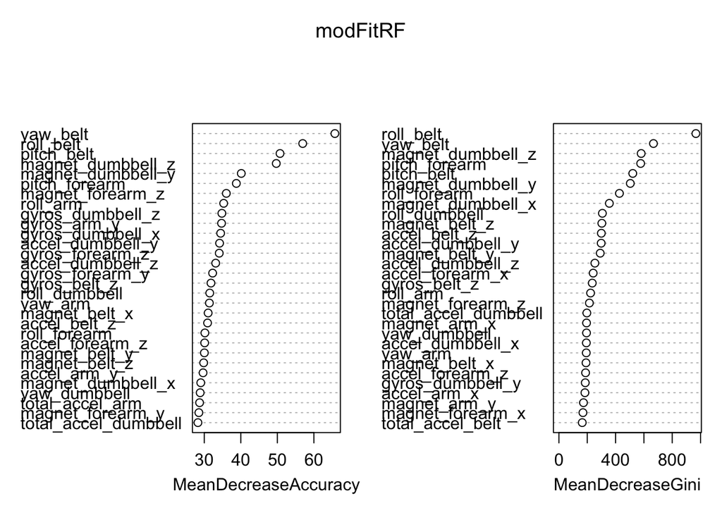

```r
importanceRF <- importance(modFitRF, type=1)
varImpPlot(modFitRF)
```

To minize predictors, we will build a random forest model 2 again with 7 most accurate predictors : “yaw_belt”, “roll_belt”, “pitch_belt”, “magnet_dumbbell_z”, “magnet_dumbbell_y”, “pitch_forearm, and”magnet_forearm_z"

## 5.4 Random forest 2

We will use random forest model with 7 predictorors

```r
training2 <- subset(training, select = c("yaw_belt", "roll_belt", "pitch_belt", "magnet_dumbbell_z", "magnet_dumbbell_y", "pitch_forearm", "magnet_forearm_z", "classe"))
set.seed(2585)
modFitRF2 <- randomForest(classe ~., data = training2, importance = TRUE)
predictRF2 <- predict(modFitRF2, testing)
conMatRF2 <- confusionMatrix(testing$classe, predictRF2)
conMatRF2
```

```
## Confusion Matrix and Statistics
##
##           Reference
## Prediction    A    B    C    D    E
##          A 1389    1    2    2    1
##          B    7  932    6    4    0
##          C    1    2  848    4    0
##          D    0    0   12  792    0
##          E    0    4    4    2  891
##
## Overall Statistics
##
##                Accuracy : 0.9894
##                  95% CI : (0.9861, 0.9921)
##     No Information Rate : 0.2849
##     P-Value [Acc > NIR] : < 2e-16
##
##                   Kappa : 0.9866
##  Mcnemar's Test P-Value : 0.00192
##
## Statistics by Class:
##
##                      Class: A Class: B Class: C Class: D Class: E
## Sensitivity            0.9943   0.9925   0.9725   0.9851   0.9989
## Specificity            0.9983   0.9957   0.9983   0.9971   0.9975
## Pos Pred Value         0.9957   0.9821   0.9918   0.9851   0.9889
## Neg Pred Value         0.9977   0.9982   0.9941   0.9971   0.9998
## Prevalence             0.2849   0.1915   0.1778   0.1639   0.1819
## Detection Rate         0.2832   0.1900   0.1729   0.1615   0.1817
## Detection Prevalence   0.2845   0.1935   0.1743   0.1639   0.1837
## Balanced Accuracy      0.9963   0.9941   0.9854   0.9911   0.9982
```

# 6 Project submission

```r
#Apply models to the 20 test cases
pml_write_files = function(x){
  n = length(x)
  for(i in 1:n){
    filename = paste0("problem_id_",i,".txt")
    write.table(x[i],file=filename,quote=FALSE,row.names=FALSE,col.names=FALSE)
  }
}

answers <- predict(modFitRF, pmlTesting)

pml_write_files(answers)
```

# 7 Reference

[1] Velloso, E.; Bulling, A.; Gellersen, H.; Ugulino, W.; Fuks, H. Qualitative Activity Recognition of Weight Lifting Exercises. Proceedings of 4th International Conference in Cooperation with SIGCHI (Augmented Human ’13) . Stuttgart, Germany: ACM SIGCHI, 2013.

[2] Ugulino, W.; Cardador, D.; Vega, K.; Velloso, E.; Milidiu, R.; Fuks, H. Wearable Computing: Accelerometers’ Data Classification of Body Postures and Movements. Proceedings of 21st Brazilian Symposium on Artificial Intelligence. Advances in Artificial Intelligence - SBIA 2012. In: Lecture Notes in Computer Science. , pp. 52-61. Curitiba, PR: Springer Berlin / Heidelberg, 2012. ISBN 978-3-642-34458-9. DOI: 10.1007/978-3-642-34459-6_6.